```r
R01_01 <- "../R/01_01_bst.R"
source(R01_01)
```

```r
stargazer::stargazer(t(data.frame("value" = data)),
          header=FALSE, type='latex',
          title="Survival Times (Days) for Patients with Breast Cancer",
          label = "tab:original")
```

[output not shown]

## Bootstrap-t

Use the bootstrap-$t$ method to construct $95 \%$ CI for the mean survival time. *When doing the bootstrap, work with the data on the natural log scale and then exponentiate the resulting interval boundaries.* Interpret the resulting interval.

We are 95% confident that the true value of mean survival time is between 296.8852574 and 2034.9199081.

```r
cat(paste0("  CODE FILENAME: ", R01_01, paste(rep("-", 43), collapse = "")))
```

```
##   CODE FILENAME: ../R/01_01_bst.R-------------------------------------------
```

```r
cat(paste(readLines(R01_01), collapse="\n"),collapse = "\n")
```

```
##       data <- c(24, 40, 719, 727, 791, 1166, 1235, 1581, 1804, 3460, 3808)
##       log_data <- log(data)
##       sample_mean <- mean(log_data)
##       seed <- 7
##       B1 <- 1000; B2 <- 25
##       n <- length(data)
##
##       bootstrap_fn <- function(data = log_data, meth = "percentile") {
##         # taking 1st level boot
##         boot <- sample(data, n, replace = TRUE)
##
##         est_boot <- mean(boot)
##         if (meth == "percentile") {
##           return(est_boot)
##         } else if (meth == "bootstrap_t") {
##           sample_est <- mean(data)
##           #taking 2nd level boot
##           est_boot2 <- replicate(B2, {
##             boot2 <- sample(data, n, replace = TRUE)
##             mean(boot2)
##           })
##         }
##
##         se_boot <- sd(est_boot2)
##         t_boot <- (est_boot - sample_est) / se_boot
##         result_list <- list(r = est_boot, t = t_boot)
##         return(result_list)
##       }
##
##       set.seed(seed)
##       res = sapply(1:B1, function(.){bootstrap_fn(data = log_data,
##                                                   meth = "bootstrap_t")})
##       ses <- unlist(res[1,])
##       tbs <- unlist(res[2,])
##       se_mean <- sd(ses) #bootstrap estimate of the SE
##       lower <- sample_mean - quantile(tbs,.975)*se_mean
##       upper <- sample_mean - quantile(tbs,.025)*se_mean
##       #c(exp(lower),exp(upper))
##       #97.5%      2.5%
##       #296.8853 2034.9199
```

```r
cat(paste0("  ", "end",paste(rep("-", 75), collapse = "")))
```

```
##   end---------------------------------------------------------------------------
```

## BCa

Use the $BCa$ method to construct a $95 \%$ CI for the mean survival time.

```r
R01_02 <- "../R/01_02_bca.R"
source(R01_02)
```

We are 95% confident that the true value of mean survival time is between 213.9662033 and 1448.1353995.

```r
cat(paste0("  CODE FILENAME: ", R01_02, paste(rep("-", 43), collapse = "")))
```

```
##   CODE FILENAME: ../R/01_02_bca.R-------------------------------------------
```

```r
cat(paste(readLines(R01_02), collapse="\n"),collapse = "\n")
```

```
##       B <- 1000
##
##       plug_in_estimator <- function(data) return(mean(data))
##
##       theta_hat_star <- c()
##       set.seed(seed)
##       for (b in 1:B) {
##         bs_sample <- sample(log_data, n, replace = TRUE)
##         theta_hat_star[b] <- plug_in_estimator(bs_sample)
##       }
##
##       # helper functions=====================================================
##
##       bias_correction <- function(bootstrap_estimates,
##                                   plug_in_estimate,
##                                   B){
##         return(qnorm(sum(bootstrap_estimates < plug_in_estimate)/B))
##       }
##
##       acceleration_parameter <- function(data = log_data){
##
##         th.jack <- sapply(1:n, function(x){plug_in_estimator(data[-x])})
##
##         L <- mean(th.jack) - th.jack
##
##         return( sum(L^3)/(6 * sum(L^2)^1.5) )
##       }
##
##       alpha <- function(confid = .975,
##                         bootstrap_estimates = theta_hat_star,
##                         plug_in_estimate = plug_in_estimate,
##                         data = log_data){
##
##         bc <- bias_correction(bootstrap_estimates = bootstrap_estimates,
##                               plug_in_estimate = plug_in_estimate,
##                               B = B)
##
##         ap <- acceleration_parameter(data)
##
##         return(pnorm(bc + (bc + qnorm(confid))/(1-(ap*(bc + qnorm(confid))))))
```

[output cut: 12 more lines]

```
##                                 bootstrap_estimates = bootstrap_estimates,
##                                 plug_in_estimate = plug_in_estimate))))
##       }
##
##       # BCa for mean computation ============================================
##
##       plug_in_estimate <- plug_in_estimator(log_data)
##
##       theta_BCa <- BC_a(confid = .975,
##                         bootstrap_estimates = theta_hat_star,
##                         plug_in_estimate = plug_in_estimate)
##
##       # exp(theta_BCa)
##       # 0.8089557%  94.63577%
##       # 213.9662  1448.1354
```

```r
cat(paste0("  ", "end",paste(rep("-", 75), collapse = "")))
```

```
##   end---------------------------------------------------------------------------
```

## Comparison

Compare your intervals.

Both intervals (shown below - NOT yet exponentiated) for $BSt$ and $BCa$ contain the sample mean survival time, 6.5586034. It is a bit wider for $BSt$ (upper - lower: 1.924866) than $BCa$ (upper - lower: 1.912214). Upon exponentiation, the difference between the two CI’s became larger. $BSt$ (upper - lower: 1738.0346508) is hugely wider than that of $BCa$ (upper - lower: 1234.1691961).

Both of these CI’s are second order accurate but $BCa$ is range preserving and transformation respecting, unlike $BSt$

```r
R01_03 <- "../R/01_03_compare.R"
source(R01_03)
```

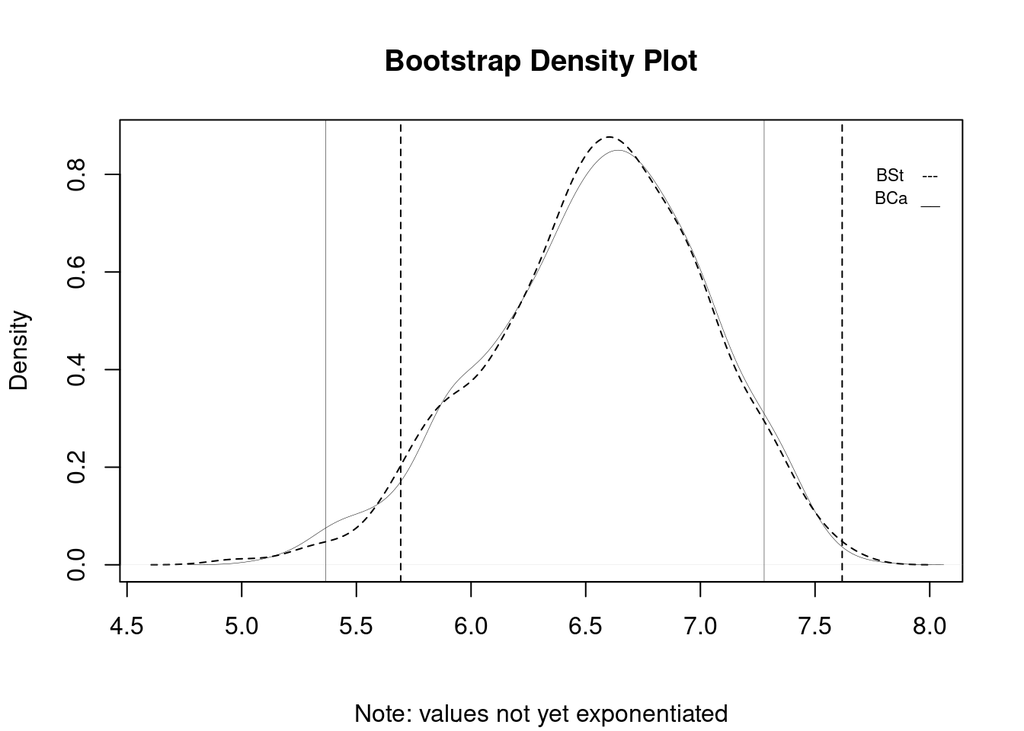

```r
cat(paste0("  CODE FILENAME: ", R01_03, paste(rep("-", 43), collapse = "")))
```

```
##   CODE FILENAME: ../R/01_03_compare.R-------------------------------------------
```

```r
cat(paste(readLines(R01_03), collapse="\n"),collapse = "\n")
```

```
##       res_median <- ses
##       plot(density(res_median),
##            ylim = range(density(res_median)$y, density(ses)$y),
##            lty = 'dashed', main = "Bootstrap Density Plot", xlab = '')
##       lines(density(theta_hat_star), lwd = 0.25)
##
##       abline(v=(theta_BCa[1]), lwd = 0.25)
##       abline(v=(theta_BCa[2]), lwd = 0.25)
##
##       abline(v=(lower),lty = 'dashed')
##       abline(v=(upper),lty = 'dashed')
##
##       text(7.9, 0.8, "BSt    ---", cex=0.7)
##       text(7.9, 0.75, "BCa   __", cex=0.7)
##       title(
##         sub="Note: values not yet exponentiated")
```

```r
cat(paste0("  ", "end",paste(rep("-", 75), collapse = "")))
```

```
##   end---------------------------------------------------------------------------
```